# King_TakeHome_Solution_SidaYe_Report slides

## King's Super Math Saga Experiment Analysis Report

#### Author: Sida Ye

#### Date: 07/18/2019

### Part 1: Import data from GCP to Python

```python
project_id='king-ds-recruit-candidate-252'
```

```python
client = bigquery.Client(project=project_id)
```

```python
job_config = bigquery.QueryJobConfig()
job_config.use_legacy_sql = False
```

```python
def query_data(query):
    df = client.query(query, project=project_id).to_dataframe()
    return df
```

### Part 2: Data Exploration

#### 1) Sanity Check

#### a) Number of players in group A and group B

```python
query_data(count_query)
```

|  | abtest_group | num_player |
| --- | --- | --- |
| 0 | A | 8265610 |
| 1 | B | 2065446 |

**Comment:** We can see that the ratio between group A and group B is 4, which follows the original design requirement.

#### b) Number of players in group A and group B by assignment date

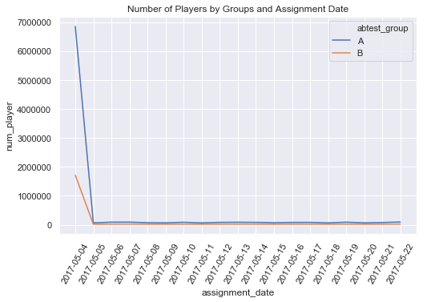

```python
plt.figure(figsize=(8, 5))
ax = sns.lineplot(x="assignment_date", y="num_player", hue="abtest_group", data=count_by_date_df)
ax.set_title('Number of Players by Groups and Assignment Date')
plt.xticks(rotation=60)
plt.show()
```

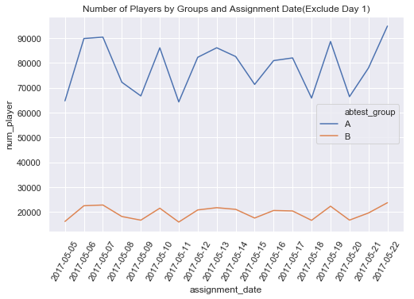

```python
plt.figure(figsize=(8, 5))
ax = sns.lineplot(x="assignment_date", y="num_player", hue="abtest_group", data=count_by_date_df[count_by_date_df['assignment_date']!='2017-05-04'])
ax.set_title('Number of Players by Groups and Assignment Date(Exclude Day 1)')
plt.xticks(rotation=60)
plt.show()
```

#### c) Ratio of number of players in group A and group B by assignment date

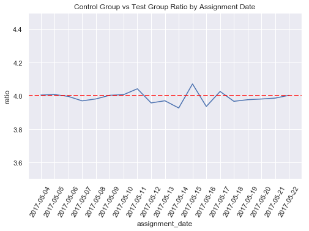

```python
plt.figure(figsize=(8, 5))
ax = sns.lineplot(x="assignment_date", y="ratio", data=ratio_df)
ax.axhline(y = 4, color='red', linewidth=2, alpha=.7, ls='--')
plt.xticks(rotation=60)
plt.ylim(3.5,4.5)
ax.set_title('Control Group vs Test Group Ratio by Assignment Date')
plt.show()
```

**Comment:** Based on previous plots, we can see that the overall distribution of group A and group B follows the original experiment design. Though most of players got assigned on the first day of the experiment, we should be fine so far

#### d) Old and new player ratio by assignment date

**Note:** Novelty effect is a common issue during AB test. The most common way to check for novelty effect is by segmenting players in new vs old. I defined new players as their assginment date and install date are same.

```python
pd.merge(new_player_df[new_player_df['abtest_group']=='A'], new_player_df[new_player_df['abtest_group']=='B'], on='assignment_date')
```

|  | assignment_date | abtest_group_x | num_new_player_x | num_old_player_x | num_player_x | abtest_group_y | num_new_player_y | num_old_player_y | num_player_y |
| --- | --- | --- | --- | --- | --- | --- | --- | --- | --- |
| 0 | 2017-05-04 | A | 76809 | 6776037 | 6852846 | B | 19114 | 1692085 | 1711199 |
| 1 | 2017-05-05 | A | 64692 | 0 | 64692 | B | 16142 | 0 | 16142 |
| 2 | 2017-05-06 | A | 89802 | 0 | 89802 | B | 22469 | 0 | 22469 |
| 3 | 2017-05-07 | A | 90366 | 0 | 90366 | B | 22763 | 0 | 22763 |
| 4 | 2017-05-08 | A | 72190 | 0 | 72190 | B | 18131 | 0 | 18131 |
| 5 | 2017-05-09 | A | 66689 | 0 | 66689 | B | 16658 | 0 | 16658 |
| 6 | 2017-05-10 | A | 86062 | 0 | 86062 | B | 21478 | 0 | 21478 |
| 7 | 2017-05-11 | A | 64274 | 0 | 64274 | B | 15900 | 0 | 15900 |
| 8 | 2017-05-12 | A | 82243 | 0 | 82243 | B | 20781 | 0 | 20781 |
| 9 | 2017-05-13 | A | 86080 | 0 | 86080 | B | 21680 | 0 | 21680 |
| 10 | 2017-05-14 | A | 82545 | 0 | 82545 | B | 21019 | 0 | 21019 |
| 11 | 2017-05-15 | A | 71322 | 0 | 71322 | B | 17517 | 0 | 17517 |
| 12 | 2017-05-16 | A | 80914 | 0 | 80914 | B | 20556 | 0 | 20556 |
| 13 | 2017-05-17 | A | 81994 | 0 | 81994 | B | 20365 | 0 | 20365 |
| 14 | 2017-05-18 | A | 65832 | 0 | 65832 | B | 16594 | 0 | 16594 |
| 15 | 2017-05-19 | A | 88612 | 0 | 88612 | B | 22282 | 0 | 22282 |
| 16 | 2017-05-20 | A | 66396 | 0 | 66396 | B | 16678 | 0 | 16678 |
| 17 | 2017-05-21 | A | 77937 | 0 | 77937 | B | 19550 | 0 | 19550 |
| 18 | 2017-05-22 | A | 94814 | 0 | 94814 | B | 23684 | 0 | 23684 |

**Comment:** Old players only got assigned on 2017-05-04. While, new players got assigned each day during the experiment In order to avoid selection bias. I would like to do the test analysis by looking at old player and new player separately.

#### 2) Player Comprehensive View Table

**Discussion:**

First, I would like to think about the high level objective: increase revenue, increase engagement

1. metric1: avg number of active days per player for each group
2. metric2: avg number of gamerounds per player for each group
3. metric3: avg number of purchases per player for each group
4. metric4: avg conversion rate for each group

**Note:** Each player has different assignment date so the durations they exposed to the treatment are different I would like to use average for the daily number of game rounds when they were assigned to one of the group

#### 3) Metrics Thinking

```python
metric_df = query_data(metric_query); metric_df
```

|  | abtest_group | ind_new_player | num_player | avg_daily_num_activity_date | avg_daily_num_purchases | avg_daily_num_gameends | num_conversion | conversion_rate |
| --- | --- | --- | --- | --- | --- | --- | --- | --- |
| 0 | A | 0 | 6776037 | 0.717696 | 0.021861 | 9.461203 | 3487 | 0.000515 |
| 1 | A | 1 | 1489573 | 0.542452 | 0.016857 | 7.148687 | 29348 | 0.019702 |
| 2 | B | 0 | 1692085 | 0.717639 | 0.023505 | 9.280231 | 900 | 0.000532 |
| 3 | B | 1 | 373361 | 0.542892 | 0.016874 | 7.053720 | 7472 | 0.020013 |

**Note:**

By thinking carefully, since the distribution of avg_daily_num_purchases is a skewed distribution which most cases are 0. And if you have too many metrics to check, it would be easier to increase false positive rate. We can use bonferroni correction to deal with it. But here, I prefer to look at these two metrics. One is related to engagement, and another is related to revenue

**Metrics**

1. Average daily number of game rounds
2. Average conversion rate

```python
metric_df[['abtest_group', 'ind_new_player', 'avg_daily_num_gameends', 'conversion_rate', 'num_player', 'num_conversion']]
```

|  | abtest_group | ind_new_player | avg_daily_num_gameends | conversion_rate | num_player | num_conversion |
| --- | --- | --- | --- | --- | --- | --- |
| 0 | A | 0 | 9.461203 | 0.000515 | 6776037 | 3487 |
| 1 | A | 1 | 7.148687 | 0.019702 | 1489573 | 29348 |
| 2 | B | 0 | 9.280231 | 0.000532 | 1692085 | 900 |
| 3 | B | 1 | 7.053720 | 0.020013 | 373361 | 7472 |

### Part 3: A/B Test Result Analysis

#### 1) Engagement

**Hypothesis:**

- H0: The number of average daily game rounds is no difference between control group and test group
- H1: The number of average daily game rounds in treatment group is larger than that in control group

**Note:** Analyze overall first, then look at new player and old player

```python
overall_gameends_test_df = query_data(overall_gameends_test_query); overall_gameends_test_df
```

|  | abtest_group | num_player | average | total | stdev | variance |
| --- | --- | --- | --- | --- | --- | --- |
| 0 | A | 8265610 | 9.044457 | 7.475795e+07 | 7.519965 | 56.549870 |
| 1 | B | 2065446 | 8.877755 | 1.833652e+07 | 7.379099 | 54.451106 |

```python
calculate_p_value(overall_gameends_test_df, method='continuous')
```

```
The p value is 0.0. So, the result is statistically significant
```

```python
new_old_gameends_test_df = query_data(new_old_gameends_test_query); new_old_gameends_test_df
```

|  | abtest_group | ind_new_player | num_player | average | total | stdev | variance |
| --- | --- | --- | --- | --- | --- | --- | --- |
| 0 | A | 0 | 6776037 | 9.461203 | 6.410946e+07 | 7.404921 | 54.832860 |
| 1 | A | 1 | 1489573 | 7.148687 | 1.064849e+07 | 7.744453 | 59.976553 |
| 2 | B | 0 | 1692085 | 9.280231 | 1.570294e+07 | 7.256309 | 52.654017 |
| 3 | B | 1 | 373361 | 7.053720 | 2.633584e+06 | 7.650784 | 58.534492 |

```python
calculate_p_value(new_old_gameends_test_df[new_old_gameends_test_df['ind_new_player']==0], method='continuous')
```

```
The p value is 0.0. So, the result is statistically significant
```

```python
calculate_p_value(new_old_gameends_test_df[new_old_gameends_test_df['ind_new_player']==1], method='continuous')
```

```
The p value is 0.0. So, the result is statistically significant
```

**Conclusion:**

New players in both control group and treatment group have less average daily game rounds played than that of old players

#### 2) Conversion Rate

**Hypothesis:**

- H0: conversion rate is no difference between control group and test group
- H1: conversion rate in treatment group is larger than that in control group

**Note:** Analyze overall first, then look at new player and old player

```python
overall_conversion_test_df = query_data(overall_conversion_test_query); overall_conversion_test_df
```

|  | abtest_group | num_player | num_conversion | conversion_rate |
| --- | --- | --- | --- | --- |
| 0 | A | 8265610 | 32835 | 0.003972 |
| 1 | B | 2065446 | 8372 | 0.004053 |

```python
calculate_p_value(overall_conversion_test_df, method='proportion')
```

```
The p value is 0.0495. So, the result is statistically significant
```

```python
new_old_conversion_test_df = query_data(new_old_conversion_test_query); new_old_conversion_test_df
```

|  | abtest_group | ind_new_player | num_player | num_conversion | conversion_rate |
| --- | --- | --- | --- | --- | --- |
| 0 | A | 0 | 6776037 | 3487 | 0.000515 |
| 1 | A | 1 | 1489573 | 29348 | 0.019702 |
| 2 | B | 0 | 1692085 | 900 | 0.000532 |
| 3 | B | 1 | 373361 | 7472 | 0.020013 |

```python
calculate_p_value(new_old_conversion_test_df[new_old_conversion_test_df['ind_new_player']==0], method='proportion')
```

```
The p value is 0.1884. So, the result is NOT statistically significant
```

```python
calculate_p_value(new_old_conversion_test_df[new_old_conversion_test_df['ind_new_player']==1], method='proportion')
```

```
The p value is 0.1114. So, the result is NOT statistically significant
```

### Part 5: Further Analysis

I would like to analyze how long a player would spend on the game daily. This would be helpful to understand whether increasing game difficulty will affect the time player spending on the game.